# EDF 6938 Lecture 5: Modern Regression Methods

EDF 6938

September 28, 2015

Linear models, both in the standard and generalized forms, have been a staple of analysis for decades. We’ll review the existing tools in R that cover what you may have already learned, before introducing a powerful new toolkit that lets us work not only with very large data sets, but is also built for future predictive accuracy.

## Linear Models in R

First, let’s get some data. Here’s one data set that’s useful:

```r
library(dplyr)
```

```r
library(ggplot2)

london.schools <- read.table("http://www.acthomas.ca/FSSS/data/school-frame.txt")
```

What are the variables within?

Y = end-of-year exam scores for each pupil (1..1978) school = school each pupil is in (1..38) LRT = London reading test score – beginning of year VR.1 = 1 for highest verbal-reasoning pupils, else 0 – beginning of year VR.2 = 1 for medium verbal-reasoning pupils, else 0 – beginning of year Gender : 0 = female, 1 = male (we think! This is the cardinal sin of data collection) School.gender.1 = 1 for all-girl schools School.gender.2 = 1 for all-boy schools School.denom.1 = 1 for Roman Catholic schools, 0 else School.denom.2 = 1 for Church of England schools, 0 else

Let’s convert these to factors for ease of use and readability.

```r
london.processed =
  london.schools %>% mutate (
    SchoolGender = factor(c("Co-ed", "All-Girl", "All-Boy")[1+School.gender.1+2*School.gender.2]),
    SchoolDenom = factor(c("Other", "RC", "C-of-E")[1+School.denom.1+2*School.denom.2]),
    VerbalScore = factor(c("Low", "Med", "High")[1+VR.2+2*VR.1])
    ) %>% select (Y, school, LRT, VerbalScore, Gender, SchoolGender, SchoolDenom)
head(london.processed)
```

```
##            Y school      LRT VerbalScore Gender SchoolGender SchoolDenom
## 1 -0.6058763      1 -10.6193         Low      1        Co-ed       Other
## 2  0.9911532      1   8.3807        High      1        Co-ed       Other
## 3 -1.5640939      1 -12.6193         Low      0        Co-ed       Other
## 4  0.1127870      1  14.3807         Med      1        Co-ed       Other
## 5  0.7515988      1   9.3807        High      0        Co-ed       Other
## 6  0.5918959      1   2.3807         Med      1        Co-ed       Other
```

Exploring the data a little: what kind of outcomes are we looking at?

```r
summary(london.processed)
```

```
##        Y                 school           LRT            VerbalScore
##  Min.   :-2.123054   Min.   : 1.00   Min.   :-34.61930   High: 521
##  1st Qu.:-0.765579   1st Qu.: 6.00   1st Qu.: -7.61930   Low : 297
##  Median :-0.046916   Median :12.00   Median :  0.38070   Med :1160
##  Mean   : 0.000153   Mean   :13.56   Mean   :  0.00001
##  3rd Qu.: 0.751598   3rd Qu.:21.00   3rd Qu.:  8.38070
##  Max.   : 3.546400   Max.   :38.00   Max.   : 37.38070
##      Gender         SchoolGender  SchoolDenom
##  Min.   :0.0000   All-Boy : 671   C-of-E: 398
##  1st Qu.:0.0000   All-Girl: 239   Other :1460
##  Median :1.0000   Co-ed   :1068   RC    : 120
##  Mean   :0.6112
##  3rd Qu.:1.0000
##  Max.   :1.0000
```

```
## stat_bin: binwidth defaulted to range/30. Use 'binwidth = x' to adjust this.
```

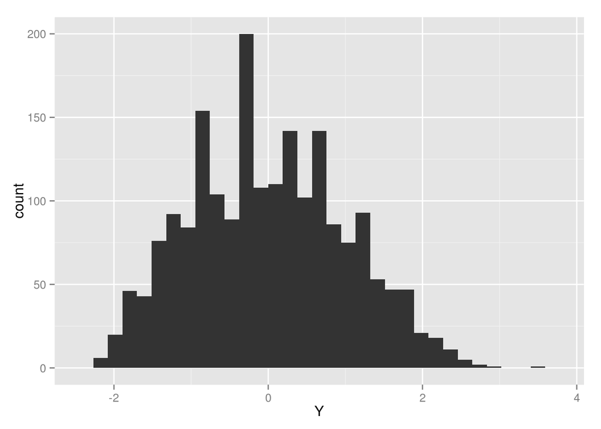

```r
qplot (Y, data=london.processed)
```

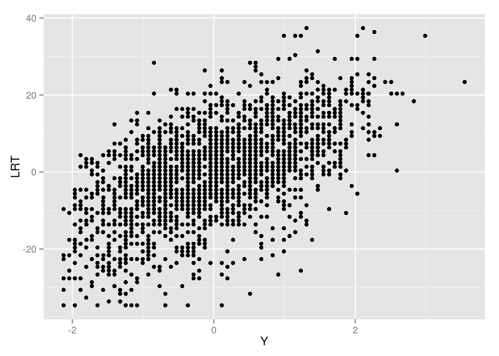

```r
qplot (Y, LRT, data=london.processed)
```

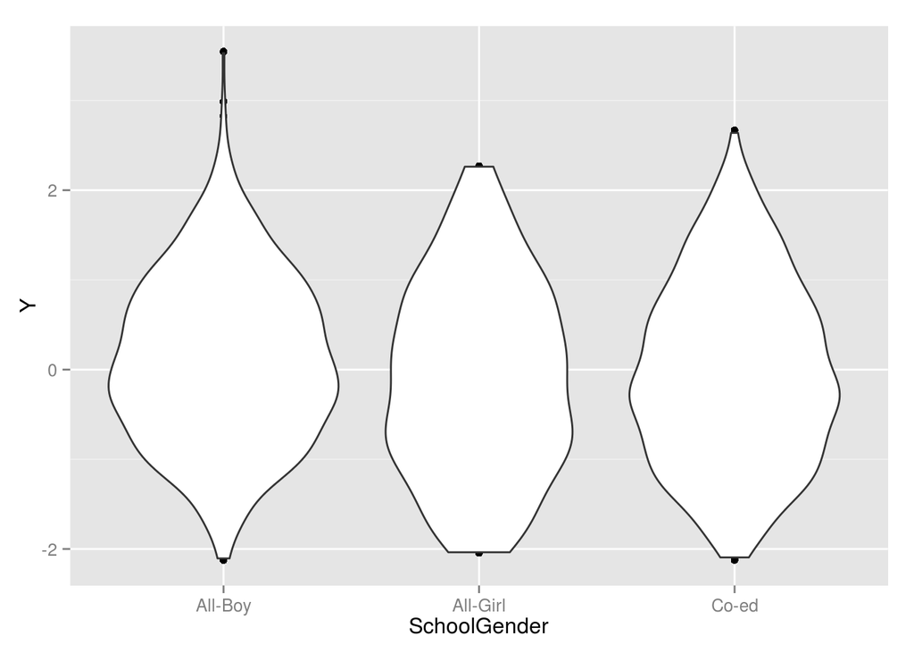

```r
qplot (SchoolGender, Y, data=london.processed) + geom_violin()
```

## Linear Models, I

R’s basic function for this is `lm()`, or “linear model”, which is the standard

$y_i = x_i\beta + \varepsilon_i$

This uses the standard formula approach

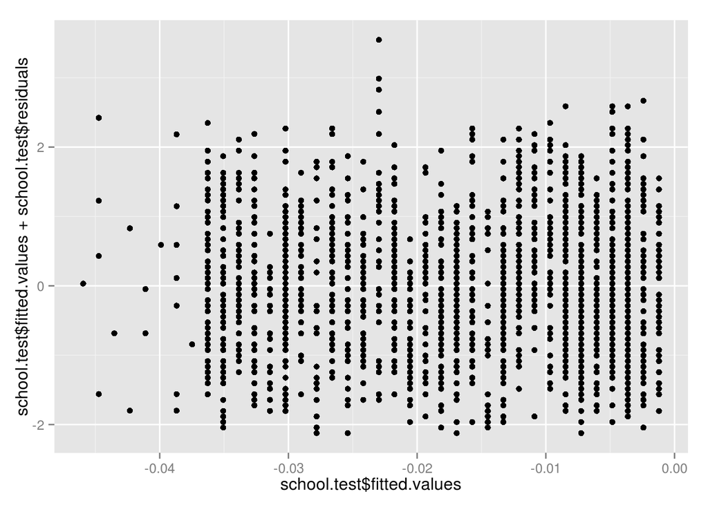

```r
school.test = lm (Y ~ school - 1, data=london.processed)   ## -1: remove the intercept.
qplot(school.test$fitted.values, school.test$fitted.values + school.test$residuals)
```

```r
summary(school.test)
```

```
##
## Call:
## lm(formula = Y ~ school - 1, data = london.processed)
##
## Residuals:
##     Min      1Q  Median      3Q     Max
## -2.1158 -0.7496 -0.0385  0.7589  3.5694
##
## Coefficients:
##         Estimate Std. Error t value Pr(>|t|)
## school -0.001209   0.001382  -0.875    0.382
##
## Residual standard error: 1.002 on 1977 degrees of freedom
## Multiple R-squared:  0.0003869,  Adjusted R-squared:  -0.0001187
## F-statistic: 0.7652 on 1 and 1977 DF,  p-value: 0.3818
```

Whoops! “School” should have been a factor.

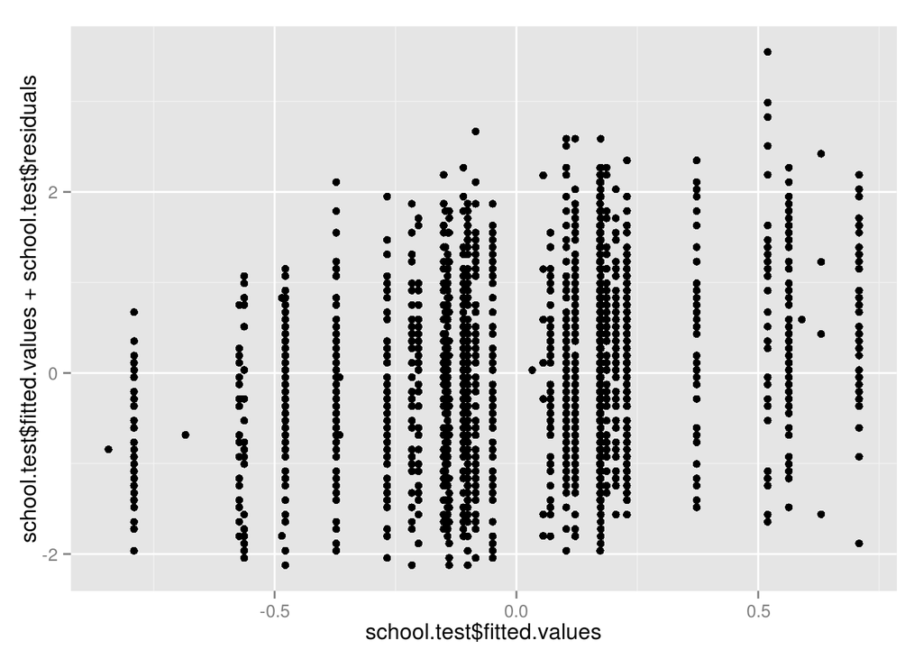

```r
london.processed <- mutate (london.processed, school = as.factor(school))
school.test = lm (Y ~ school - 1, data=london.processed)   ## -1: remove the intercept.
qplot(school.test$fitted.values, school.test$fitted.values + school.test$residuals)
```

```r
summary(school.test)
```

```
##
## Call:
## lm(formula = Y ~ school - 1, data = london.processed)
##
## Residuals:
##      Min       1Q   Median       3Q      Max
## -2.59210 -0.70901 -0.05141  0.69268  3.02675
##
## Coefficients:
##          Estimate Std. Error t value Pr(>|t|)
## school1   0.07031    0.14057   0.500 0.617002
## school2  -0.08427    0.12239  -0.688 0.491230
## school3   0.17449    0.06849   2.548 0.010920 *
## school4   0.10313    0.10103   1.021 0.307442
## school5  -0.14219    0.10273  -1.384 0.166488
## school6  -0.10078    0.08586  -1.174 0.240588
## school7   0.12158    0.08872   1.370 0.170704
## school8   0.37267    0.12995   2.868 0.004178 **
## school9   0.70860    0.15432   4.592 4.68e-06 ***
## school10  0.56346    0.11280   4.995 6.40e-07 ***
## school11 -0.37253    0.10159  -3.667 0.000252 ***
## school12 -0.56288    0.18900  -2.978 0.002936 **
## school13  0.17322    0.15844   1.093 0.274404
## school14 -0.47789    0.11280  -4.237 2.37e-05 ***
## school15 -0.26731    0.11128  -2.402 0.016396 *
## school16 -0.20252    0.15432  -1.312 0.189552
## school17 -0.79079    0.12765  -6.195 7.09e-10 ***
## school18  0.20578    0.10843   1.898 0.057865 .
## school19  0.51965    0.14871   3.494 0.000486 ***
## school20 -0.14673    0.13910  -1.055 0.291630
## school21 -0.21612    0.14871  -1.453 0.146283
## school22  0.18650    0.11954   1.560 0.118883
## school23 -0.13905    0.18900  -0.736 0.461992
## school24  0.22836    0.15634   1.461 0.144260
## school25 -0.10966    0.11519  -0.952 0.341224
## school26 -0.57321    0.20547  -2.790 0.005326 **
## school27 -0.15043    0.13115  -1.147 0.251517
## school28  0.17268    0.13910   1.241 0.214623
## school29 -0.04917    0.11437  -0.430 0.667341
## school30  0.22857    0.12442   1.837 0.066341 .
## school31 -0.84361    0.96373  -0.875 0.381484
## school32  0.05547    0.36425   0.152 0.878988
## school33  0.59036    0.96373   0.613 0.540225
## school34 -0.36562    0.68146  -0.537 0.591654
## school35 -0.48512    0.68146  -0.712 0.476621
## school36 -0.68428    0.96373  -0.710 0.477766
## school37  0.63019    0.48186   1.308 0.191088
## school38  0.03270    0.96373   0.034 0.972933
## ---
## Signif. codes:  0 '***' 0.001 '**' 0.01 '*' 0.05 '.' 0.1 ' ' 1
##
## Residual standard error: 0.9637 on 1940 degrees of freedom
## Multiple R-squared:  0.0928, Adjusted R-squared:  0.07503
## F-statistic: 5.222 on 38 and 1940 DF,  p-value: < 2.2e-16
```

A quick note on internals: What is this actually producing for us on the back end?

```r
names(school.test)
```

```
##  [1] "coefficients"  "residuals"     "effects"       "rank"
##  [5] "fitted.values" "assign"        "qr"            "df.residual"
##  [9] "contrasts"     "xlevels"       "call"          "terms"
## [13] "model"
```

Let’s expand to some more variables.

```r
school.test.2 = lm (Y ~ SchoolGender + SchoolDenom + VerbalScore + LRT, data=london.processed)
summary(school.test.2)
```

```
##
## Call:
## lm(formula = Y ~ SchoolGender + SchoolDenom + VerbalScore + LRT,
##     data = london.processed)
##
## Residuals:
##      Min       1Q   Median       3Q      Max
## -2.18711 -0.55273 -0.03934  0.53669  2.68215
##
## Coefficients:
##                       Estimate Std. Error t value Pr(>|t|)
## (Intercept)           0.738456   0.057806  12.775  < 2e-16 ***
## SchoolGenderAll-Girl -0.117046   0.058886  -1.988 0.046985 *
## SchoolGenderCo-ed    -0.140138   0.039540  -3.544 0.000403 ***
## SchoolDenomOther     -0.213182   0.044702  -4.769 1.99e-06 ***
## SchoolDenomRC        -0.431028   0.084444  -5.104 3.64e-07 ***
## VerbalScoreLow       -0.902504   0.076529 -11.793  < 2e-16 ***
## VerbalScoreMed       -0.561817   0.047544 -11.817  < 2e-16 ***
## LRT                   0.029979   0.001965  15.258  < 2e-16 ***
## ---
## Signif. codes:  0 '***' 0.001 '**' 0.01 '*' 0.05 '.' 0.1 ' ' 1
##
## Residual standard error: 0.7789 on 1970 degrees of freedom
## Multiple R-squared:  0.3983, Adjusted R-squared:  0.3961
## F-statistic: 186.3 on 7 and 1970 DF,  p-value: < 2.2e-16
```

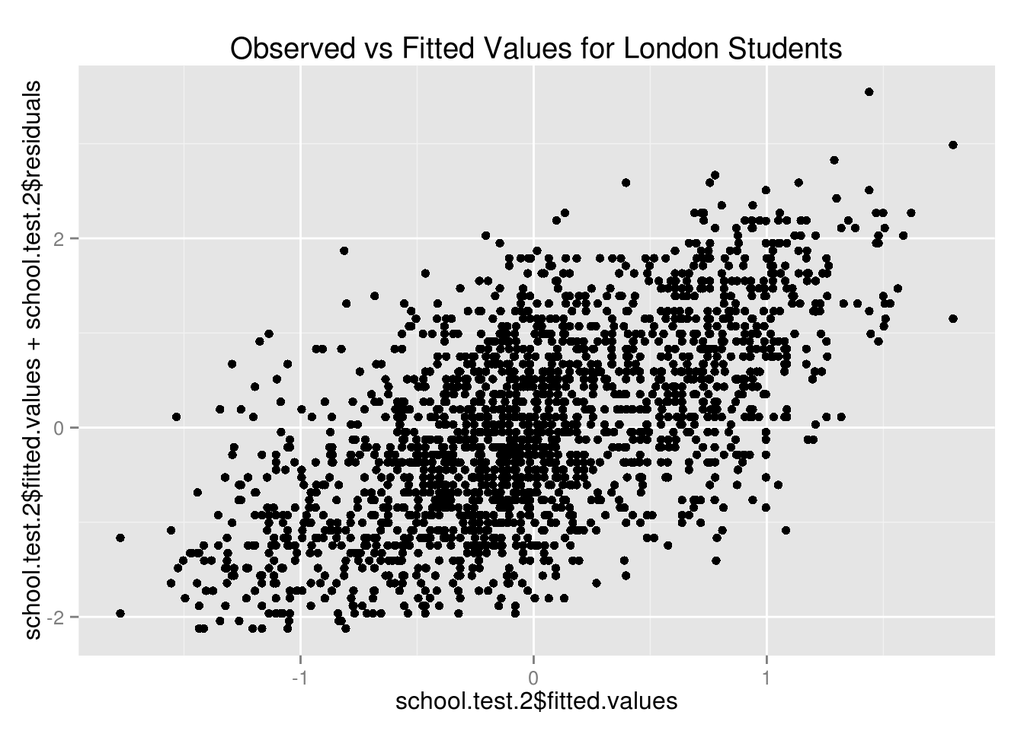

```r
qplot(school.test.2$fitted.values, school.test.2$fitted.values + school.test.2$residuals, main="Observed vs Fitted Values for London Students")
```

And finally, both together:

```r
school.test.3 = lm (Y ~ school + SchoolGender + SchoolDenom + VerbalScore + LRT, data=london.processed)
summary(school.test.3)
```

```
##
## Call:
## lm(formula = Y ~ school + SchoolGender + SchoolDenom + VerbalScore +
##     LRT, data = london.processed)
##
## Residuals:
##      Min       1Q   Median       3Q      Max
## -2.00583 -0.55276 -0.01581  0.52843  2.41345
##
## Coefficients: (4 not defined because of singularities)
##                        Estimate Std. Error t value Pr(>|t|)
## (Intercept)           0.5365402  0.1171731   4.579 4.97e-06 ***
## school2              -0.0774031  0.1467926  -0.527 0.598049
## school3              -0.1032023  0.1232540  -0.837 0.402520
## school4              -0.2435186  0.1366752  -1.782 0.074949 .
## school5              -0.4153207  0.1372002  -3.027 0.002502 **
## school6              -0.1438180  0.1297206  -1.109 0.267708
## school7              -0.0970114  0.1309481  -0.741 0.458881
## school8              -0.0008109  0.1509775  -0.005 0.995715
## school9               0.3566103  0.1647723   2.164 0.030566 *
## school10              0.3277673  0.1420061   2.308 0.021097 *
## school11             -0.4701090  0.1366352  -3.441 0.000593 ***
## school12             -0.3964224  0.1858075  -2.134 0.033008 *
## school13              0.2575294  0.1670051   1.542 0.123226
## school14             -0.2010877  0.1424347  -1.412 0.158173
## school15             -0.0287633  0.1417426  -0.203 0.839214
## school16              0.1283903  0.1649085   0.779 0.436337
## school17             -0.6455754  0.1497065  -4.312 1.70e-05 ***
## school18              0.2993778  0.1399202   2.140 0.032509 *
## school19              0.2548761  0.1613880   1.579 0.114436
## school20              0.1397827  0.1560457   0.896 0.370481
## school21              0.1310489  0.1617580   0.810 0.417951
## school22              0.0738977  0.1454427   0.508 0.611449
## school23             -0.0182294  0.1857502  -0.098 0.921832
## school24              0.2132538  0.1655753   1.288 0.197915
## school25             -0.1978619  0.1431888  -1.382 0.167185
## school26             -0.1459295  0.1968192  -0.741 0.458517
## school27             -0.0905009  0.1514049  -0.598 0.550083
## school28              0.1797174  0.1557842   1.154 0.248794
## school29             -0.1327794  0.1427089  -0.930 0.352269
## school30              0.3013795  0.1478743   2.038 0.041678 *
## school31             -0.8774677  0.7667803  -1.144 0.252618
## school32             -0.1005857  0.3076793  -0.327 0.743766
## school33             -0.3002780  0.7673292  -0.391 0.695597
## school34             -0.1972370  0.5479110  -0.360 0.718901
## school35             -0.7606831  0.5479467  -1.388 0.165223
## school36             -0.3447712  0.7669828  -0.450 0.653110
## school37             -0.0535641  0.3961508  -0.135 0.892459
## school38             -0.9823895  0.7673707  -1.280 0.200627
## SchoolGenderAll-Girl         NA         NA      NA       NA
## SchoolGenderCo-ed            NA         NA      NA       NA
## SchoolDenomOther             NA         NA      NA       NA
## SchoolDenomRC                NA         NA      NA       NA
## VerbalScoreLow       -0.9208669  0.0758291 -12.144  < 2e-16 ***
## VerbalScoreMed       -0.5767573  0.0468119 -12.321  < 2e-16 ***
## LRT                   0.0311139  0.0019568  15.900  < 2e-16 ***
## ---
## Signif. codes:  0 '***' 0.001 '**' 0.01 '*' 0.05 '.' 0.1 ' ' 1
##
## Residual standard error: 0.7587 on 1937 degrees of freedom
## Multiple R-squared:  0.4387, Adjusted R-squared:  0.4271
## F-statistic: 37.85 on 40 and 1937 DF,  p-value: < 2.2e-16
```

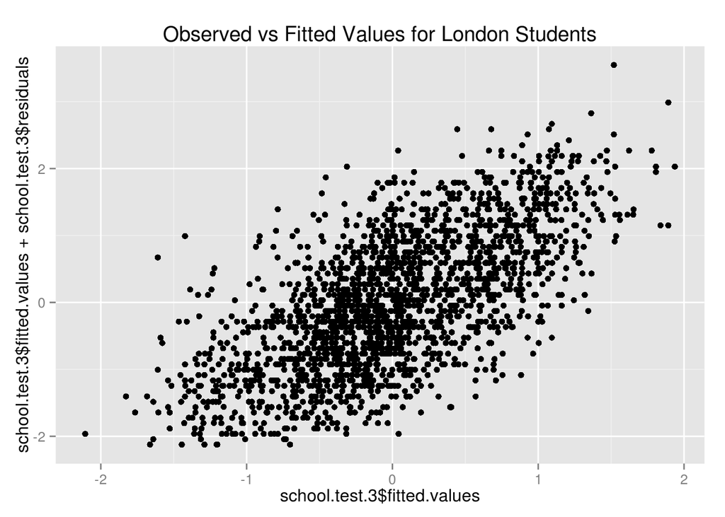

```r
qplot(school.test.3$fitted.values, school.test.3$fitted.values + school.test.3$residuals, main="Observed vs Fitted Values for London Students")
```

Keep these for later; we’re going to use them when comparing to results from the methods that follow.

## Example, II: Housing prices in California and Pennsylvania

```r
calif_penn <- read.csv("http://www.acthomas.ca/7474/data/calif_penn_2011.csv")
head(calif_penn, 2)
```

```
##   X.1 X    GEO.id2 STATEFP COUNTYFP TRACTCE POPULATION LATITUDE LONGITUDE
## 1   1 1 6001400100       6        1  400100       2937 37.85942 -122.2304
## 2   2 2 6001400200       6        1  400200       1974 37.84829 -122.2495
##                               GEO.display.label Median_house_value
## 1 Census Tract 4001, Alameda County, California                 NA
## 2 Census Tract 4002, Alameda County, California             909600
##   Total_units Vacant_units Median_rooms Mean_household_size_owners
## 1        1425          162          6.5                       2.02
## 2         929           37          6.0                       2.53
##   Mean_household_size_renters Built_2005_or_later Built_2000_to_2004
## 1                        1.59                 4.6                9.3
## 2                        1.81                 0.0                1.2
##   Built_1990s Built_1980s Built_1970s Built_1960s Built_1950s Built_1940s
## 1        50.9         2.5         4.8         1.3        13.9         2.8
## 2         0.0         1.3         6.1         6.5         1.0        10.8
##   Built_1939_or_earlier Bedrooms_0 Bedrooms_1 Bedrooms_2 Bedrooms_3
## 1                   9.9        3.6        5.6       11.9       40.6
## 2                  73.2        3.0       16.4       27.4       34.4
##   Bedrooms_4 Bedrooms_5_or_more Owners Renters Median_household_income
## 1       31.6                6.7   81.2    18.8                  156250
## 2       17.5                1.2   66.0    34.0                  111667
##   Mean_household_income
## 1                237805
## 2                195229
```

Subset this to Pennsylvania.

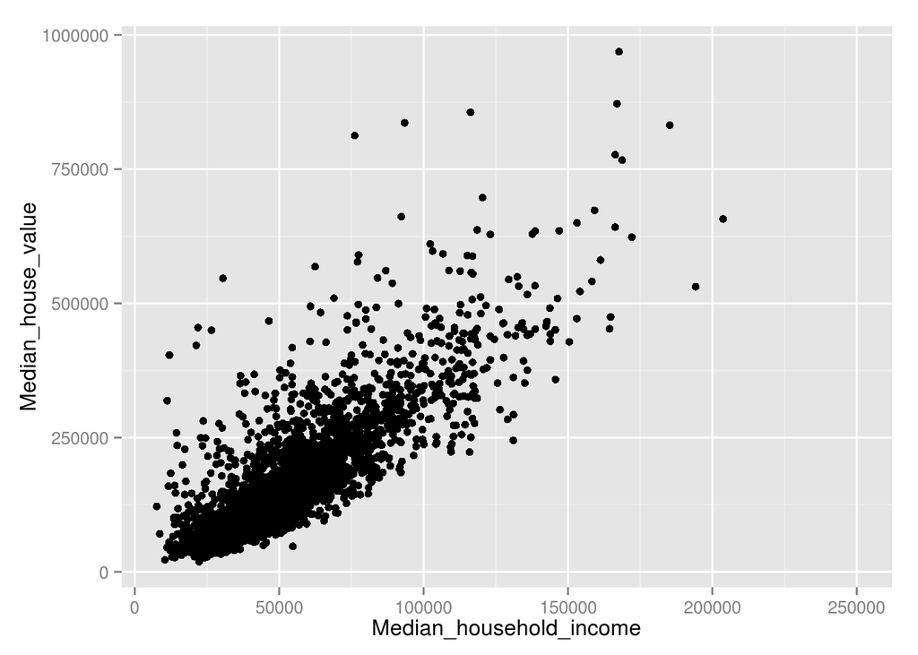

```r
penn <- filter (calif_penn, STATEFP==42)
qplot (Median_household_income, Median_house_value, data=penn)
```

```r
housing.model <- lm(Median_house_value ~ Median_household_income, data=penn)
summary(housing.model)
```

```
##
## Call:
## lm(formula = Median_house_value ~ Median_household_income, data = penn)
##
## Residuals:
##     Min      1Q  Median      3Q     Max
## -207567  -36051  -11257   21146  560715
##
## Coefficients:
##                           Estimate Std. Error t value Pr(>|t|)
## (Intercept)             -2.621e+04  2.696e+03  -9.721   <2e-16 ***
## Median_household_income  3.651e+00  4.516e-02  80.851   <2e-16 ***
## ---
## Signif. codes:  0 '***' 0.001 '**' 0.01 '*' 0.05 '.' 0.1 ' ' 1
##
## Residual standard error: 63000 on 3166 degrees of freedom
##   (50 observations deleted due to missingness)
## Multiple R-squared:  0.6737, Adjusted R-squared:  0.6736
## F-statistic:  6537 on 1 and 3166 DF,  p-value: < 2.2e-16
```

More data, please.

```r
penn.2 = penn %>% mutate (mean.bedrooms = (Bedrooms_1 + 2*Bedrooms_2 + 3*Bedrooms_3 + 4*Bedrooms_4 + 5*Bedrooms_5_or_more)/100)
head(penn.2, 2)
```

```
##    X.1    X     GEO.id2 STATEFP COUNTYFP TRACTCE POPULATION LATITUDE
## 1 8058 8058 42001030101      42        1   30101       2580 40.01581
## 2 8059 8059 42001030102      42        1   30102       5780 39.95308
##   LONGITUDE                               GEO.display.label
## 1 -77.08117 Census Tract 301.01, Adams County, Pennsylvania
## 2 -77.03621 Census Tract 301.02, Adams County, Pennsylvania
##   Median_house_value Total_units Vacant_units Median_rooms
## 1             207200        1016           94          6.6
## 2             198900        2472          249          6.3
##   Mean_household_size_owners Mean_household_size_renters
## 1                       2.84                        2.53
## 2                       2.57                        2.64
##   Built_2005_or_later Built_2000_to_2004 Built_1990s Built_1980s
## 1                 2.5               10.1        19.5        22.5
## 2                 5.8                7.2        15.3        31.8
##   Built_1970s Built_1960s Built_1950s Built_1940s Built_1939_or_earlier
## 1        16.3         5.9         7.8         1.0                  14.4
## 2        14.1         4.7         5.3         3.9                  12.0
##   Bedrooms_0 Bedrooms_1 Bedrooms_2 Bedrooms_3 Bedrooms_4
## 1          0          1        9.3       68.3       16.1
## 2          0          2       17.0       63.8       14.6
##   Bedrooms_5_or_more Owners Renters Median_household_income
## 1                5.3   90.0    10.0                   68036
## 2                2.5   86.5    13.5                   61646
##   Mean_household_income mean.bedrooms
## 1                 77132         3.154
## 2                 83407         2.983
```

```r
housing.model.2 <- lm(Median_house_value ~ mean.bedrooms, data=penn.2)
summary(housing.model.2)
```

```
##
## Call:
## lm(formula = Median_house_value ~ mean.bedrooms, data = penn.2)
##
## Residuals:
##     Min      1Q  Median      3Q     Max
## -245790  -65879  -25693   36956  700582
##
## Coefficients:
##               Estimate Std. Error t value Pr(>|t|)
## (Intercept)    -140485      12768  -11.00   <2e-16 ***
## mean.bedrooms   113434       4588   24.73   <2e-16 ***
## ---
## Signif. codes:  0 '***' 0.001 '**' 0.01 '*' 0.05 '.' 0.1 ' ' 1
##
## Residual standard error: 101000 on 3166 degrees of freedom
##   (50 observations deleted due to missingness)
## Multiple R-squared:  0.1618, Adjusted R-squared:  0.1616
## F-statistic: 611.3 on 1 and 3166 DF,  p-value: < 2.2e-16
```

## Introducing Penalized Estimation

```r
install.packages("glmnet")
```

The `glmnet` package covers a very general form of regression solution that is also very powerful: the “elastic net” family of penalized estimation.

(diversion: to the blackboard!)

It has two prime features for our sake:

- it can be used to greatly speed up calculations for standard but large linear models
- it has a built-in tool for cross validation to check the out-of-sample goodness of fit for a model class.

There is, of course, one major drawback: we need to work a little harder to make it work properly. But the benefits will most often outweight the drawbacks.

```r
library(glmnet)
school.test.net = glmnet (london.processed$school, london.processed$Y)
```

Won’t work because you have to do the factor decomposition yourself. So let’s do it!

```r
design.matrix <- model.matrix(~ 0 + school, london.processed)
head(design.matrix)
```

```
##   school1 school2 school3 school4 school5 school6 school7 school8 school9
## 1       1       0       0       0       0       0       0       0       0
## 2       1       0       0       0       0       0       0       0       0
## 3       1       0       0       0       0       0       0       0       0
## 4       1       0       0       0       0       0       0       0       0
## 5       1       0       0       0       0       0       0       0       0
## 6       1       0       0       0       0       0       0       0       0
##   school10 school11 school12 school13 school14 school15 school16 school17
## 1        0        0        0        0        0        0        0        0
## 2        0        0        0        0        0        0        0        0
## 3        0        0        0        0        0        0        0        0
## 4        0        0        0        0        0        0        0        0
## 5        0        0        0        0        0        0        0        0
## 6        0        0        0        0        0        0        0        0
##   school18 school19 school20 school21 school22 school23 school24 school25
```

[output cut: 20 more lines]

```r
school.test.net = glmnet (design.matrix,
                          london.processed$Y)
school.test.net
```

```
##
## Call:  glmnet(x = design.matrix, y = london.processed$Y)
##
##       Df     %Dev    Lambda
##  [1,]  0 0.000000 0.1362000
##  [2,]  1 0.003139 0.1241000
##  [3,]  1 0.005745 0.1131000
##  [4,]  2 0.009154 0.1031000
##  [5,]  4 0.013840 0.0939100
##  [6,]  4 0.019630 0.0855700
##  [7,]  5 0.025120 0.0779600
##  [8,]  6 0.030780 0.0710400
##  [9,]  7 0.035890 0.0647300
## [10,]  9 0.041360 0.0589800
## [11,] 11 0.046780 0.0537400
```

[output cut: 54 more lines]

```r
names(school.test.net)
```

```
##  [1] "a0"        "beta"      "df"        "dim"       "lambda"
##  [6] "dev.ratio" "nulldev"   "npasses"   "jerr"      "offset"
## [11] "call"      "nobs"
```

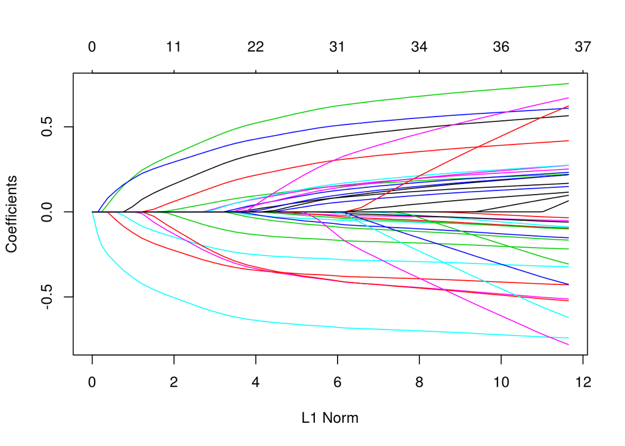

```r
plot(school.test.net)
```

```r
school.test.net$beta
```

```
## 38 x 65 sparse Matrix of class "dgCMatrix"
```

```
##    [[ suppressing 65 column names 's0', 's1', 's2' ... ]]
```

```
##
## school1  .  .           .          .           .            .
## school2  .  .           .          .           .            .
## school3  .  .           .          .           .            .
## school4  .  .           .          .           .            .
## school5  .  .           .          .           .            .
## school6  .  .           .          .           .            .
## school7  .  .           .          .           .            .
## school8  .  .           .          .           .            .
## school9  .  .           .          .           0.042844290  0.10140283
## school10 .  .           .          0.03231769  0.080132744  0.12248304
## school11 .  .           .          .           .            .
## school12 .  .           .          .           .            .
## school13 .  .           .          .           .            .
## school14 .  .           .          .          -0.001768911 -0.04465345
## school15 .  .           .          .           .            .
## school16 .  .           .          .           .            .
## school17 . -0.07235061 -0.1382738 -0.19711242 -0.249223376 -0.29792329
## school18 .  .           .          .           .            .
## school19 .  .           .          .           .            .
## school20 .  .           .          .           .            .
## school21 .  .           .          .           .            .
## school22 .  .           .          .           .            .
## school23 .  .           .          .           .            .
## school24 .  .           .          .           .            .
## school25 .  .           .          .           .            .
## school26 .  .           .          .           .            .
## school27 .  .           .          .           .            .
## school28 .  .           .          .           .            .
## school29 .  .           .          .           .            .
## school30 .  .           .          .           .            .
## school31 .  .           .          .           .            .
## school32 .  .           .          .           .            .
## school33 .  .           .          .           .            .
## school34 .  .           .          .           .            .
## school35 .  .           .          .           .            .
## school36 .  .           .          .           .            .
## school37 .  .           .          .           .            .
## school38 .  .           .          .           .            .
##
```

[output cut: 452 more lines]

```
## school24  0.27283363  0.27322786  0.27358982  0.27392204
## school25 -0.05940282 -0.05952212 -0.05962807 -0.05972220
## school26 -0.52098805 -0.52128215 -0.52154738 -0.52178665
## school27 -0.09982197 -0.09997243 -0.10010679 -0.10022682
## school28  0.21752831  0.21788892  0.21822022  0.21852449
## school29  .           .           .           .
## school30  0.27374766  0.27407963  0.27438482  0.27466529
## school31 -0.77501181 -0.77676078 -0.77835166 -0.77979882
## school32  0.09544171  0.09623563  0.09696175  0.09762575
## school33  0.61739719  0.61934057  0.62111402  0.62273231
## school34 -0.30311158 -0.30431951 -0.30541740 -0.30641538
## school35 -0.42260954 -0.42381747 -0.42491537 -0.42591334
## school36 -0.61568152 -0.61743051 -0.61902141 -0.62046858
## school37  0.66762859  0.66864816  0.66957988  0.67043121
## school38  0.05974143  0.06168479  0.06345823  0.06507651
```

Compare to the earlier one.

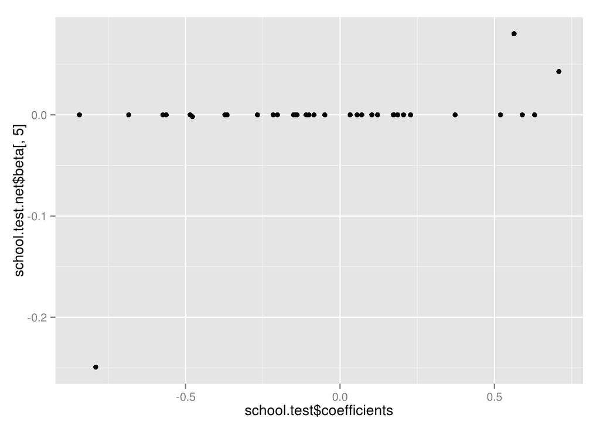

```r
qplot (school.test$coefficients, school.test.net$beta[,5])
```

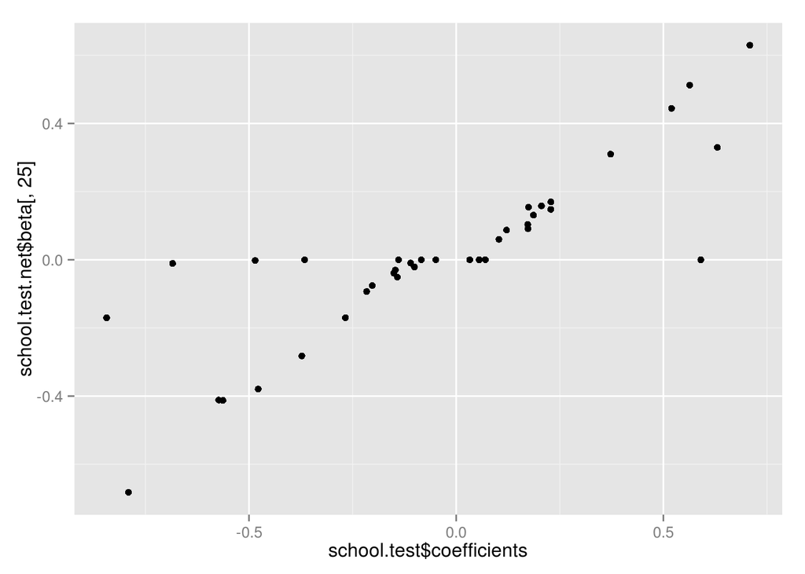

```r
qplot (school.test$coefficients, school.test.net$beta[,25])
```

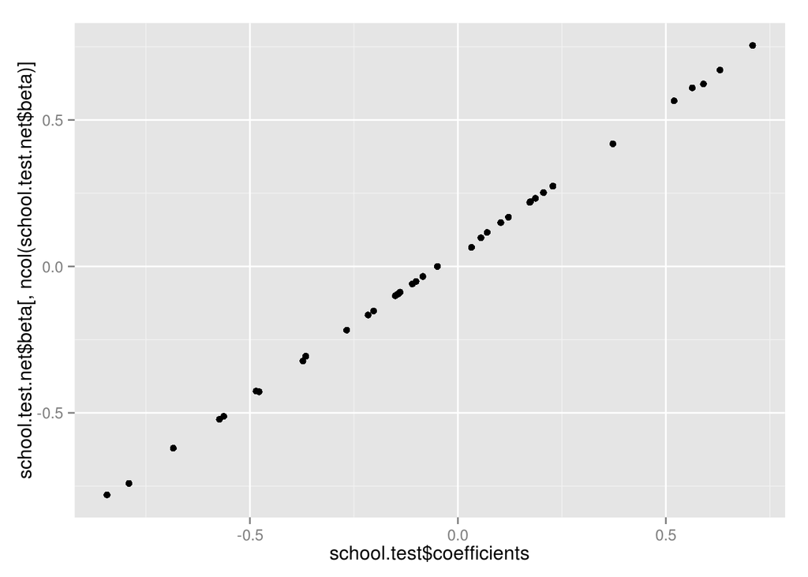

```r
qplot (school.test$coefficients, school.test.net$beta[,ncol(school.test.net$beta)])
```

Well, that’s all well and good. But `alpha=1` sets up the pure “LASSO” form. What about the “ridge” form?

```r
school.test.net.2 = glmnet (design.matrix,
                          london.processed$Y,
                          alpha=0)
school.test.net.2
```

```
##
## Call:  glmnet(x = design.matrix, y = london.processed$Y, alpha = 0)
##
##        Df      %Dev    Lambda
##   [1,] 38 1.936e-37 136.20000
##   [2,] 38 1.528e-03 124.10000
##   [3,] 38 1.675e-03 113.10000
##   [4,] 38 1.836e-03 103.10000
##   [5,] 38 2.012e-03  93.91000
##   [6,] 38 2.205e-03  85.57000
##   [7,] 38 2.416e-03  77.96000
##   [8,] 38 2.646e-03  71.04000
##   [9,] 38 2.898e-03  64.73000
##  [10,] 38 3.173e-03  58.98000
##  [11,] 38 3.474e-03  53.74000
```

[output cut: 89 more lines]

```r
names(school.test.net.2)
```

```
##  [1] "a0"        "beta"      "df"        "dim"       "lambda"
##  [6] "dev.ratio" "nulldev"   "npasses"   "jerr"      "offset"
## [11] "call"      "nobs"
```

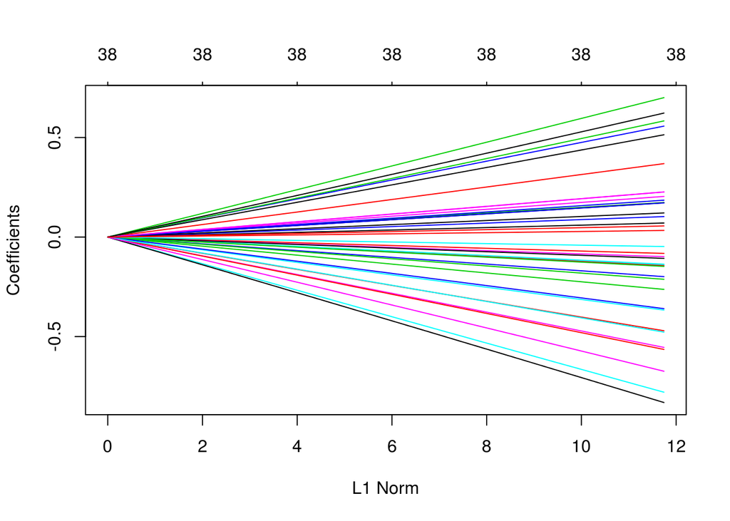

```r
plot(school.test.net.2)
```

But which one do we want to keep?

## Cross-validation To The Rescue!

Principle of cross-validation:

- hold out part of the data.
- fit the model to the initial piece.
- check the predictive accuracy on the held-out piece.

So let’s!

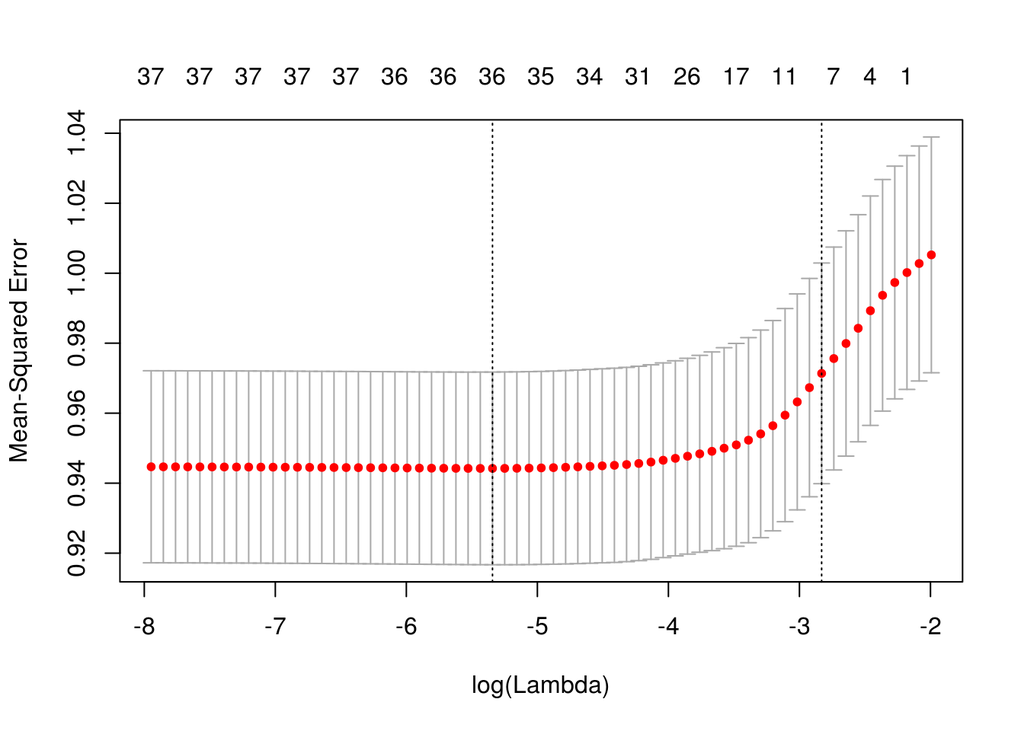

```r
school.test.cv = cv.glmnet (design.matrix, london.processed$Y, lambda=school.test.net$lambda)
plot(school.test.cv)
```

```r
picked <- which (school.test.cv$lambda == school.test.cv$lambda.min)
cv.error <- school.test.cv$cvm[picked]
```

In general, do the selection first, then redo the check with the suggested chain.

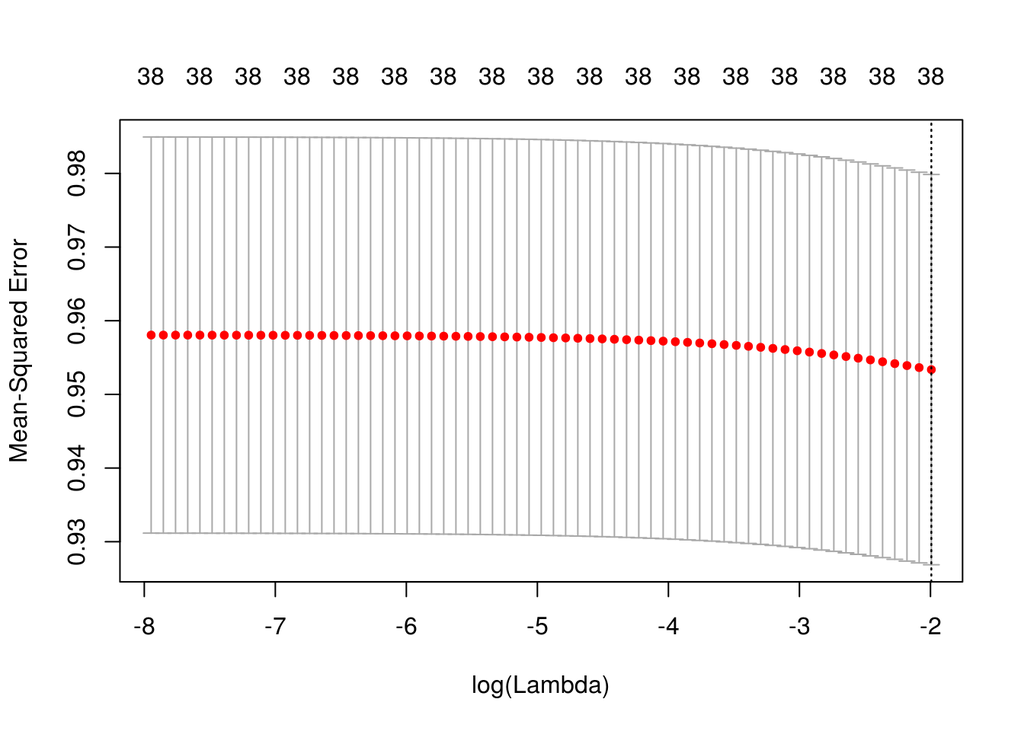

```r
school.test.cv.2 = cv.glmnet (design.matrix, london.processed$Y, lambda=school.test.net$lambda, alpha=0)
plot(school.test.cv.2)
```

```r
picked.2 <- which (school.test.cv.2$lambda == school.test.cv.2$lambda.min)

cv.error.2 <- school.test.cv.2$cvm[picked.2]

c(cv.error, cv.error.2)
```

```
## [1] 0.9442269 0.9533652
```

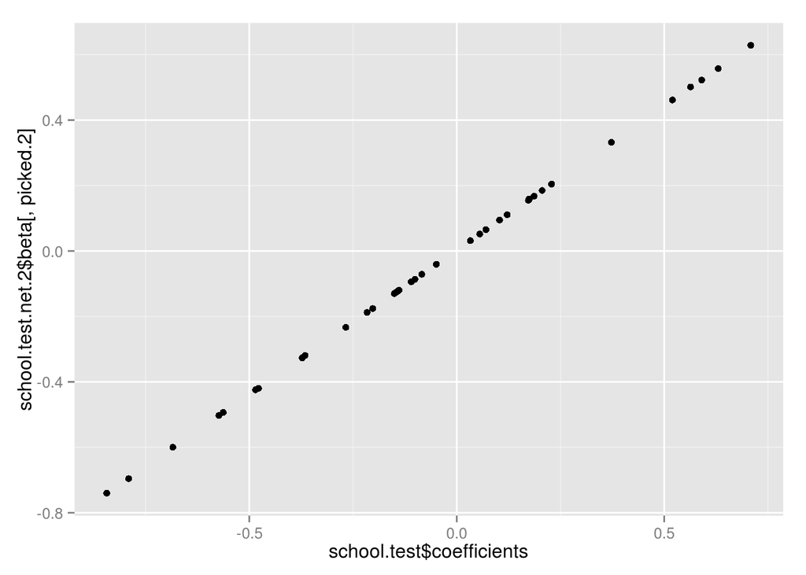

```r
school.test.net.2 = glmnet (design.matrix, london.processed$Y, alpha=0, lambda = school.test.cv.2$lambda)
qplot (school.test$coefficients, school.test.net.2$beta[,picked.2])
```